# PPS-Domains-Classifier-V3

- 1. Overview of Project
- 2. Overview of Machine Learning
- 3. Analyst Scored Domains Dataset
  - 3.1 Visualization
  - 3.2 Statistical Analysis
  - 3.3 Machine Learning Models
- 4 Inferrence Scored Domains Dataset
  - 4.1 Preprocessing
  - 4.2 Machine Learning Models
- 5 Analysis
- 6 Conclusions

# 1. Overview of Project

PPS currently uses the **Google Detection** API in order to find uses of particular pictures through out the web. Once Google Detection has found the use cases of the image, domain data is gathered, and placed in a mongodb. Based on certain input features, a rule based scoring system is in place to determine if the domain is with pursuing to prosecute.

## Current Rule Based Scoring

- **`essential.score.latest.score`**: the output of the scoring system (from 1 - 13, where 13 means the domain is valuable)
- **`essential.BellonaStatus`**: first thing they go off of. Values of `SKIP_` or `HOLD_` are given scores of zero since they are not valuable.
- **`ssential.score.latest.components.whoisScoreComponents.registrantContactCountry`**: USA gets a score of 3, some european countries, singapore, canada and austraila are given a score of 1, everything else is 0
- **`essential.score.latest.components.privateRegistrationStatus`**: If the domain is registered privately (meaning done by a domain service, that means we can't easily determine who the owner is and thus it makes it harder prosecute, so we give these a score of 0, everything else is whatever the whois score was (which isn't zero since we already filtered those out).
- **`essential.score.latest.components.alexaData.trafficData.ran`**: finally, you can get a boost from alexa based on if the site is popular. Anything below 10000 gets a bonus of 10 (so for a USA site, this gives 13), and that goes down to a bonus of 2 for a score below 500000, with scores in between.

## Idea

> Implement a supervised machine learning classification algorithm in order to better predict what domains are worth pursuing for copy right infringement

# 2. Overview of Machine Learning

Here are a few terms that are used pretty frequently and would help to have a base understanding of throughout the rest of this report.

## Input Features

- The inputs variables that the model will use to make predictions with. Ex: **`domainAge`**

## Class Labels/Output/Response

- This refers to the class or label that is associated with a set of input features. In our case it is: **`analystResult`**.

## Training example

- A training example is made up of input variables and an output label. A machine learning model will try and find a relationship (map) between the input features and the output label.

## Training

- The process of running a machine learning model on training data, during which the model's parameters will "learn" the relationship that maps the inputs to the outputs.

## Predicting

- Once a model has been trained, it can then take a new example(an **unseen** set of input features) and make a prediction of what class it will be belong to. If we know the class ahead of time, we can measure prediction accuracy as well as other performance metrics.

## Train/Test split (Cross Validation) - Preventing overfitting

- Because most machine learning models will learn their parameters based off of the data they are trained on, I want to make every effort to prevent overfitting (Seen below).

[figure not shown]

- Overfitting will occur when the model begins to tune its parameters based off of noise in the training data. This allows for the accuracy for predictions made on training data (that the model has seen before) to be very high, but often means that when new unseen test data is presented, the accuracy plummets.
- To prevent this, I will often split my data from the start into a training and testing set.
- For example, say I have 1000 labeled examples. I may split them into a training set of 800 examples and a test set of 200 examples. I would train my model with the set of 800, and then make predictions with the 200 test examples. Because the model had not seen the 200 test examples, they are a good indicator of how it may perform

## Accuracy vs. Precision vs. Recall vs. F1-Score

There are several metrics that will be used in scoring model prediction performance in this report. But first to motivate the need for these different metrics, imagine that a model has the main goal to maximize its accuracy. Now consider the following situation: the model is trying to predict which patients may have cancer. Overall, 99% of the population is cancer free, and only 1% has the disease. Now, if the model only tries to maximize accuracy, it may just predict that **no one** has cancer, and hence it would have a 99% accuracy. Therefore we need to consider a confusion matrix in order to better optimize our results and prevent the situation above from occuring.

[figure not shown]

True positive and true negatives are the observations that are correctly predicted and therefore shown in green. We want to minimize false positives and false negatives so they are shown in red color. These terms are a bit confusing. So let’s take each term one by one and understand it fully.

**True Positives (TP)** - These are the correctly predicted positive values which means that the value of actual class is yes and the value of predicted class is also yes. E.g. if actual class value indicates that domains is valuable and predicted class tells you the same thing.

**True Negatives (TN)** - These are the correctly predicted negative values which means that the value of actual class is no and value of predicted class is also no. E.g. if actual class says this domain is not valuable and predicted class tells you the same thing.

False positives and false negatives, these values occur when your actual class contradicts with the predicted class.

**False Positives (FP)** – When actual class is no and predicted class is yes. E.g. if actual class says this domain is not valuable but predicted class tells you that domain is valuable. Note, this is also refered to as **Type I error**.

**False Negatives (FN)** – When actual class is yes but predicted class in no. E.g. if actual class value indicates that this domain is valuable and predicted class tells you that domain is not valuable. Note, this is also refered to as **Type II error**.

Once you understand these four parameters then we can calculate Accuracy, Precision, Recall and F1 score.

### Accuracy

Accuracy is the most intuitive performance measure and it is simply a ratio of correctly predicted observation to the total observations. One may think that, if we have high accuracy then our model is best. Yes, accuracy is a great measure but only when you have symmetric datasets where values of false positive and false negatives are almost same. Therefore, you have to look at other parameters to evaluate the performance of your model.

### $$Accuracy = \frac{TP+TN}{TP+FP+FN+TN}$$

### Precision

"How often does the algorithm cause a false alarm?". Precision is the ratio of correctly predicted positive observations to the total predicted positive observations. The question that this metric answer is of all domains that our model labeled as worth pursuing, how many actually were worth pursuing?

### $$Precision = \frac{TP}{TP+FP}$$

### Recall

"How sensitive is our algorithm?". Recall is the ratio of correctly predicted positive observations to the all observations in actual class - yes. The question recall answers is: Of all the domains that were actually marked as worth pursuing, how many did the model classify as worth pursuing?

### $$Recall = \frac{TP}{TP+FN}$$

### F1 Score

F1 Score is the weighted average of Precision and Recall. Therefore, this score takes both false positives and false negatives into account. Intuitively it is not as easy to understand as accuracy, but F1 is usually more useful than accuracy, especially if you have an uneven class distribution. Accuracy works best if false positives and false negatives have similar cost. If the cost of false positives and false negatives are very different, it’s better to look at both Precision and Recall.er

### $$F1 = \frac{2*(Recall * Precision)}{(Recall + Precision)}$$

I am going to be using these metrics throughout this report.

# 3. Analyst Scored Domains Dataset

The first data set that I am going to run through is the analyst scored domains data set. It is comprised of:

> - **2182** domain training examples
>   - **2147** domain training examples that have been scored by an analyst. I.e. **`analystResult`** is 0 or 1.
>   - To start there will be a visualization of the dataset, followed by a statistical analysis, and then fitting a machine learning model.

Note: In order to keep this report somewhat condensed, I couldn't show the entire analysis and process that I went through. However, out of the vast number of input features that I started with, the vast majority had to be taken out. This is due to:

1. Not explaining the variance seen in the response (analyst result)
2. Introducing so much noise to the system that the model constantly overfit - (https://en.wikipedia.org/wiki/Curse_of_dimensionality)
3. Making it slightly more interpretable and more robust

# 3.1 Analyst Scored Domains Dataset: Visualization

Lets being by getting quick overview of this dataset.

```python
# standard
import pandas as pd
import numpy as np

# visualization
import matplotlib.pyplot as plt
import seaborn as sns
%matplotlib inline
```

```python
analystScoredDomains = pd.read_csv('PPSDomains.csv')
```

```python
analystScoredDomains.head()
```

|  | domain | analystResult | BellonaStatus | medianLoadTime | speedPercentile | trafficDataRank | trafficDataReachRank | reachPerMillionValue | pageViewsPerMillionValue | pageViewsRankValue | usageStatisticRankValue | reachRankValue | historyDataScore | domainAge | registrantContactCountry | privateRegistrationStatus |
| --- | --- | --- | --- | --- | --- | --- | --- | --- | --- | --- | --- | --- | --- | --- | --- | --- |
| 0 | 07449m.com | NaN | NaN | NaN | NaN | NaN | NaN | NaN | NaN | NaN | NaN | NaN | 3 | 68.0 | UNITED STATES | {"registrantName":"Domain Administrator","simi... |
| 1 | 1037kissfm.com | NaN | NaN | NaN | NaN | NaN | NaN | NaN | NaN | NaN | NaN | NaN | 3 | 6955.0 | UNITED STATES | NaN |
| 2 | 1041kqth.com | NaN | TODO | 7687.0 | 1.0 | 1941173.0 | 1872730.0 | 0.2 | 0.01 | 2322074.0 | 2025813.0 | 2060156.0 | 3 | 1251.0 | UNITED STATES | NaN |
| 3 | 1049maxcountry.com | NaN | NaN | NaN | NaN | NaN | NaN | NaN | NaN | NaN | NaN | NaN | 3 | 978.0 | UNITED STATES | NaN |
| 4 | 1053thebuzz.com | NaN | NaN | NaN | NaN | NaN | NaN | NaN | NaN | NaN | NaN | NaN | 3 | 6221.0 | UNITED STATES | NaN |

### Missing Data Heatmap

A simple heatmap to see where we are missing data is shown below (all off the yellow represents missing data):

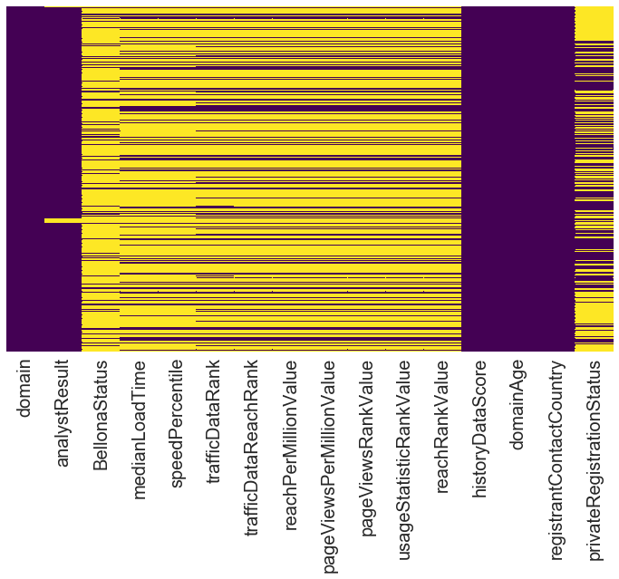

```python
plt.figure(figsize=(12,7))
sns.set(font_scale=2)
sns.heatmap(analystScoredDomains.isnull(), yticklabels=False, cbar=False, cmap='viridis')
```

The key takeaways from this are:

> 1. Most of the features are incredibly sparse
>    1. The center metrics are nearly unusable, since there are so many missing values
>    2. A few training examples must be filtered out because they do not have an **`analystResult`** class label

Based on this visualization, there are a few things that immediately come to mind. Due to the sparsity of the metric data, I am going to want to create several different data sets to train the model on.

- One dataset will **not** include the metric data at all
- A second dataset will include the metric data, and normalize all missing values to 0
- A third dataset will include the metric data- if it is present, it will be replaced by a 1, if not it will replaced by a 0. This will convert what was a continuous input feature into a binary input.

For now though, lets get back to an general visualization of our dataset, along with some preprocessing.

### Drop unlabeled training examples, and see how many domains in this set are considered valuable

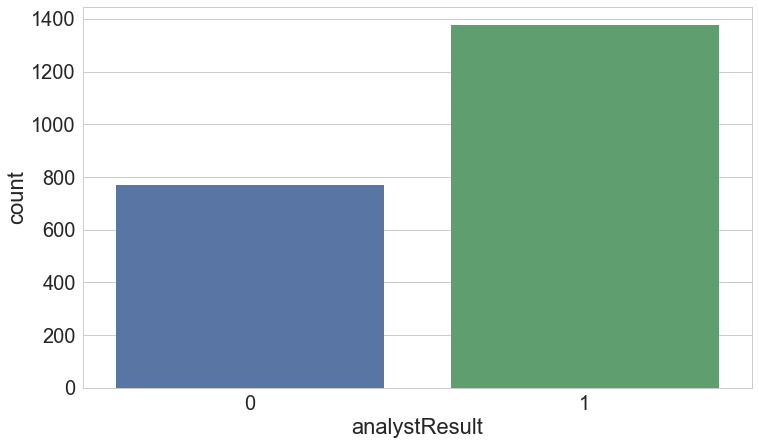

```python
analystScoredDomains = analystScoredDomains[pd.notnull(analystScoredDomains['analystResult'])]
ar = {'TRUE': 1, 'FALSE': 0, 'TRUE ': 1, 'FALSE ': 0}
analystScoredDomains['analystResult'] = analystScoredDomains['analystResult'].map(ar)

sns.set_style('whitegrid')
plt.figure(figsize=(12,7))
sns.countplot(x='analystResult', data=analystScoredDomains)
```

What is interesting about the above visual is that it is very apparent that in this case we are dealing with a situation where our dataset has approximately 66% of the examples scored as valuable, and only 33% scored as invaluable. However, in the real world only 2-10% would be considered valuable. So our classes are misrepresented in the training data, and we are also facing a **class imbalance problem**. This is something that will be taken into account throughout this report.

Now lets look at a few visual trends in the data.

### Analyst Result vs. Registrant Contact Country

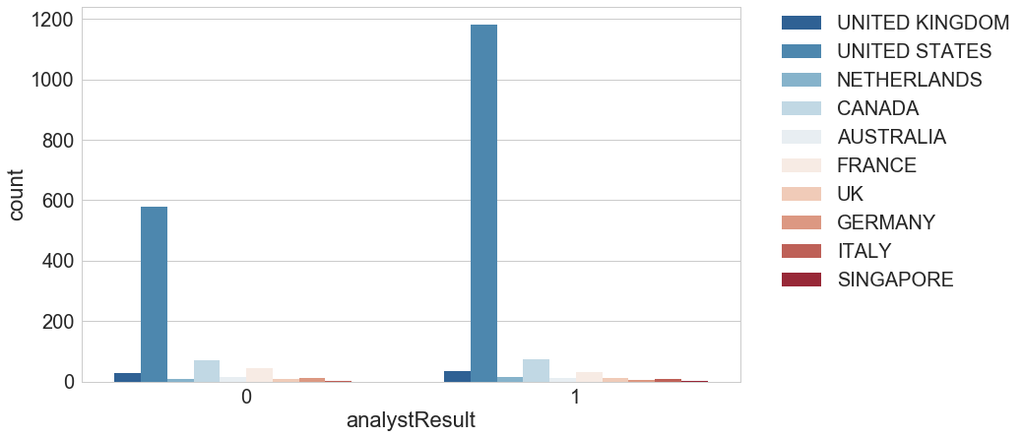

```python
plt.figure(figsize=(12,7))
sns.countplot(x='analystResult', hue='registrantContactCountry', data=analystScoredDomains, palette='RdBu_r')
plt.legend(bbox_to_anchor=(1.05, 1), loc=2, borderaxespad=0.)
```

Clearly the vast majority of Domains are coming from the US. Lets look at another countplot, but with a hue pertaining to private registration status. In order to do that first we need to engineer the data slightly: any entry that is null for privateRegistrationStatus will be marked as 0 (not privately registered), and any entry with text will be given a 1.

### Analyst Result vs. Private Registration Status

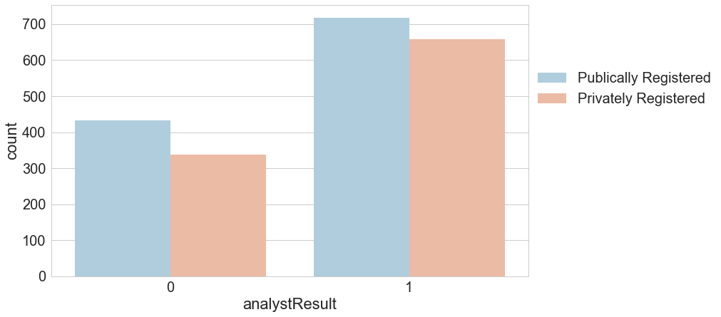

```python
analystScoredDomains['privateRegistrationStatus'] = analystScoredDomains['privateRegistrationStatus'].replace(np.nan, 0)
analystScoredDomains['privateRegistrationStatus'] = analystScoredDomains['privateRegistrationStatus'].map(lambda x: 1 if x != 0 else 0)

plt.figure(figsize=(12,7))
sns.countplot(x='analystResult', hue='privateRegistrationStatus', data=analystScoredDomains, palette='RdBu_r')
plt.legend(['Publically Registered', 'Privately Registered'], loc=9, bbox_to_anchor=(1.2, .8))
```

What is very interesting from the above visual is that while there are certainly more publically registered domains that are considered valuable, the trend is not as pronounced as may have been expected. There at still ~650 privately registered domains that were marked as worth pursuing. Based on the original rules based algorithm, these domains **all** would have been filtered out.

Now lets take a look at our last input feature that did not have any missing values, **`domainAge`**.

### Analyst Result vs. Domain Age

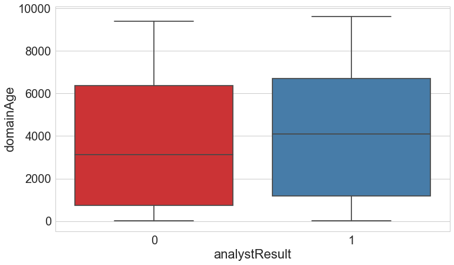

```python
plt.figure(figsize=(12,7))
sns.boxplot(x="analystResult", y="domainAge", data=analystScoredDomains,palette='Set1')
```

There is definitely a difference in the mean value of domain age above, indicating that a domain with a slightly older age may be more likely to be considered valuable. In order the determine if this is correct, further statistical testing must be conducted.

Moving on, lets take a look at the traffic data metrics (based on alexa data). Many values were missing for these metrics, and even more than that, many of the features are heavily correlated, which can mess with the model.

Lets visual a few different situation based on the alexa data.

### Analyst Result vs. Alexa Data (examples that have alexa data)

Here alexa data is mapped to a 0 or 1, based on whether it was provided or not. Note: only 661 examples had a alexa data provided.

[figure not shown]

```python
analystScoredDomains_alexaData = analystScoredDomains.copy()
analystScoredDomains_alexaData['trafficDataRank'] = analystScoredDomains_alexaData['trafficDataRank'].replace(np.nan, 0)
analystScoredDomains_alexaData['trafficDataRank'] = analystScoredDomains_alexaData['trafficDataRank'].map(lambda x: 1 if x != 0 else 0)

plt.figure(figsize=(12,7))
sns.countplot(x='analystResult', hue='trafficDataRank', data=analystScoredDomains_alexaData, palette='RdBu_r')
plt.legend(['Alexa Data Provided', 'Alexa Data not privded'], loc=9, bbox_to_anchor=(1.2, .8))
```

Above it looks as though Alexa Data being present may be a useful predictor of the analyst result, but statistical analysis will need to be considered in order to reach a conclusion.

Lets now look at a different plot comparing analyst result and alexa data. Instead of just looking at where alexa data was provided or not, a subset of the training examples where alexa data is present will be analyzed, with a goal of seeing how the specific value changes the analyst result.

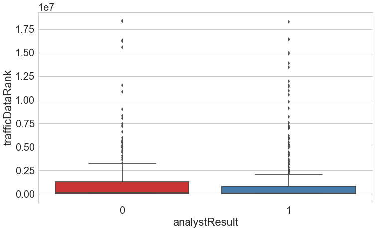

```python
analystScoredDomains_tdr = analystScoredDomains.copy()
analystScoredDomains_tdr = analystScoredDomains_tdr[pd.notnull(analystScoredDomains_tdr['trafficDataRank'])]

plt.figure(figsize=(12,7))
sns.boxplot(x="analystResult", y="trafficDataRank", data=analystScoredDomains_tdr,palette='Set1')
```

From the above box plot, there appears to be a slight difference between means, indicating that a lower traffic data rank may correlate with a analyst result of 1.

Now that the dataset has been explored visually, it is time to go through thorough statistical analysis to see which input features are most likely statistically significant.

# 3.2 Analyst Scored Domains Dataset: Statistical Analysis

- At this point, from all of the original input features, the following remain (many were removed due to overfitting (curse of dimensionality), and correlation to other features):
  > - **Registrant Contact Country**
  > - **Domain age**
  > - **Privately registered**
  > - **trafficDataRank**
  > - **Alexa Data Provided**
  > - **Reach per million**
  > - **Page views rank value**

Lets now walk through these features one by one and determine there statistical significance with an array of tests.

Note: the following analysis is created on the basis that the sample dataset (2147 examples) is an accurate representation of the population of domains as a whole. If it is not, it will invaldate the majority of this analysis. It is certainly possible that this domains dataset is not an accurate representation of the population, in which case additional conversations must be had.

## 3.2.1 Registrant Contact Country

- This is a categorical input (1 of many countries), and for this analysis we will look at whether the United States being the input is a statistically significant predictor of analyst result.
- To complete this test a contingency table must be created and a chi square test run on the data

```python
from scipy import stats
from scipy.stats import chi2, chi2_contingency

# contingency table
#           valuable   not valuable
#------------------------------
# USA     |   a            b
# Not USA |   c            d


USA_domains = analystScoredDomains[analystScoredDomains['registrantContactCountry'] == 'UNITED STATES']['analystResult']
non_USA_domains = analystScoredDomains[analystScoredDomains['registrantContactCountry'] != 'UNITED STATES']['analystResult']

USA_valuable = USA_domains.sum()
USA_nonvaluable = USA_domains.size - USA_domains.sum()

non_USA_valuable = non_USA_domains.sum()
non_USA_nonvaluable = non_USA_domains.size - non_USA_domains.sum()

T = np.array([[USA_valuable, USA_nonvaluable], [non_USA_valuable, non_USA_nonvaluable]])

chi2_contingency(T, correction=False)[1]
```

```
7.392307788257664e-10
```

## Result

The final result for the p value regarding registrant contact country and its statistical significance in predicting analyst result is seen above: **7.3923077882576635e-10**.

This means that if the registrant contact country being USA was **not** a statistically significant predictor of **analystResult**, then the values in the chi contingency table would only be seen **7.3923077882576635e-8**% of the time.

So, registrant contact country will be used a predictor.

There are two different scenarios where registrant contact country can be utilized:

> 1. It can be used as a binary input feature where if the value is USA it is a 1, and if it is not USA it is a 0.
> 2. Through the use of one-hot encoding, each country can get its own input vector, and for each training example whatever country it is associated with, that countries vector will get a 1, and all others will be given 0's.

Both of these examples are valid, and what makes the most sense is to try and each and see how it effects our prediction metrics.

## 3.2.2 Domain Age

- This is a continuous input, and a t test will be conducted to determine its statistical significance.

```python
analystScoredDomains['domainAge'] = analystScoredDomains['domainAge'].fillna(analystScoredDomains['domainAge'].mean())
domainAgeValuable = analystScoredDomains[analystScoredDomains['analystResult'] == 1]['domainAge']
domainAgeNotValuable = analystScoredDomains[analystScoredDomains['analystResult'] == 0]['domainAge']

tDomainAge, pDomainAge = stats.ttest_ind(domainAgeValuable,domainAgeNotValuable)
print("t statistic:", tDomainAge,"\tp value:", pDomainAge)
```

```
t statistic: 3.7060653326215 	p value: 0.0002158356565879612
```

## Result

The final result for the p value concerning domain age was 0.02%. This is well under the significance value of 5% that is widely accepted. Domain age will be included in the final model as an input feature.

## 3.2.3 Privately Registered

- This is a binary input, and will be determined with a chi square test.

```python
private_domains = analystScoredDomains[analystScoredDomains['privateRegistrationStatus'] == 1]['analystResult']
public_domains = analystScoredDomains[analystScoredDomains['privateRegistrationStatus'] == 0]['analystResult']

private_valuable = private_domains.sum()
private_nonvaluable = private_domains.size - private_domains.sum()

public_valuable = public_domains.sum()
public_nonvaluable = public_domains.size - public_domains.sum()

T = np.array([[private_valuable, private_nonvaluable], [public_valuable, public_nonvaluable]])

chi2_contingency(T, correction=False)[1]
```

```
0.07082488608208885
```

## Result

The final result for the p value concerning private registration status as a predictor is 7.08%. This is **not** statisically significant. This was slightly expected after the visualization seen earlier. Private registration status will be taken out as a predictor initially.

A note: It is most definitely possible that private registration status is a useful predictor in the case of the population, however, concerning this sample dataset, it was not deemed significant. If this does not match with intuition then a better sampling process will need to be designed, and the analysis repeated.

## 3.2.4 Traffic Data Rank

- This is a continuous input, and will utilize a t-test.

```python
trafficDataRankDomains = analystScoredDomains[['analystResult', 'trafficDataRank']].dropna()

trafficValuable = trafficDataRankDomains[trafficDataRankDomains['analystResult'] == 1]['trafficDataRank']
trafficNotValuable = trafficDataRankDomains[trafficDataRankDomains['analystResult'] == 0]['trafficDataRank']

t, p = stats.ttest_ind(trafficValuable,trafficNotValuable)
print("t statistic:", t,"\tp value:", p)
```

```
t statistic: -1.3537790348736618 	p value: 0.17627098174481684
```

## Result

The p value associated with traffic data rank is 17%, which again is above the significance threshold of 5%. This means that traffic data rank is not a statistically significant predictor and will not be used in the building of the model.

## 3.2.5 Alexa Data Provided

- This is a binary input and will be tested with a chi square test

```python
ad_present_domains = analystScoredDomains_alexaData[analystScoredDomains_alexaData['trafficDataRank'] == 1]['analystResult']
ad_missing_domains = analystScoredDomains_alexaData[analystScoredDomains_alexaData['trafficDataRank'] == 0]['analystResult']

ad_present_valuable = ad_present_domains.sum()
ad_present_nonvaluable = ad_present_domains.size - ad_present_domains.sum()

ad_missing_valuable = ad_missing_domains.sum()
ad_missing_nonvaluable = ad_missing_domains.size - ad_missing_domains.sum()

T = np.array([[ad_present_valuable, ad_present_nonvaluable], [ad_missing_valuable, ad_missing_nonvaluable]])

chi2_contingency(T, correction=False)[1]
```

```
0.2678841733362468
```

## Result

The p value associated with alexa data being provided was 26%. This means that it is well above the significance threshold of 5%, and will not be used in building the final model.

## 3.2.6 Reach Per Million Value

- This is a continuous value and will be determined with a t test.

```python
import locale
from locale import atof
locale.setlocale(locale.LC_NUMERIC, '')

reachPerMillionValueDomains = analystScoredDomains[['analystResult', 'reachPerMillionValue']].dropna()
reachPerMillionValueDomains['reachPerMillionValue'] = reachPerMillionValueDomains['reachPerMillionValue'].map(atof)

rpmValuable = reachPerMillionValueDomains[reachPerMillionValueDomains['analystResult'] == 1]['reachPerMillionValue']
rpmNotValuable = reachPerMillionValueDomains[reachPerMillionValueDomains['analystResult'] == 0]['reachPerMillionValue']
print(rpmValuable.mean(), "\t", rpmNotValuable.mean())

t, p = stats.ttest_ind(rpmValuable,rpmNotValuable)
print("t statistic:", t,"\tp value:", p)
```

```
208.72860139860143 	 297.1022767857143
t statistic: -1.0010357225522648 	p value: 0.3171814709261598
```

## Result

Again, we have a p value above the significance threshold of 5%, 31.7% in this case. This input will not be used in the model.

## 3.2.7 Page Views Rank Value

- This is continuous and will be determined with a t test.

```python
pvrvDomains = analystScoredDomains[['analystResult', 'pageViewsRankValue']].dropna()

pvrvValuable = pvrvDomains[pvrvDomains['analystResult'] == 1]['pageViewsRankValue']
pvrvNotValuable = pvrvDomains[pvrvDomains['analystResult'] == 0]['pageViewsRankValue']
print(pvrvValuable.mean(), "\t", pvrvNotValuable.mean())

t, p = stats.ttest_ind(pvrvValuable,pvrvNotValuable)
print("t statistic:", t,"\tp value:", p)
```

```
1272152.1491841492 	 1658886.482142857
t statistic: -1.5899704192722706 	p value: 0.1123269556603699
```

## Result

Again, this value is not statistically significant, with a p value of 11%. From the many input features that were originally present, it is clear that many are not very useful in explaining the variance seen in the response, **analyst result**.

# Statistical Analysis Recap

After testing a host of input features, the following were deemed to be statistically significant:

> - **`Registrant Contact Country`**
> - **`Domain Age`**

While the others were not deemed to be statistically significant, it will not be hard to build a few additional models that incorporate them to see if there is a synergy between them and another feature that may explain some of the variability in the response.

# 3.3 Machine Learning Models

With the initial visualization and statistical analysis out of the way, it is now time to build several predictive models.

First though, a final preprocessing must be done to get rid of uneccessary data.

### Preprocess

```python
analystScoredDomains = analystScoredDomains.drop(['historyDataScore', 'medianLoadTime','speedPercentile', 'trafficDataReachRank',
                        'reachPerMillionValue', 'pageViewsRankValue','pageViewsPerMillionValue',
                        'usageStatisticRankValue', 'reachRankValue', 'BellonaStatus', ], axis=1)
```

### Metric Function

```python
def get_metrics(cm):
    accuracy = (cm[0,0]+cm[1,1])/(cm[0,0]+cm[0,1]+cm[1,0]+cm[1,1])
    precision = cm[0,0]/(cm[0,0]+cm[1,0])
    recall = cm[0,0]/(cm[0,0]+cm[0,1])
    print('Accuracy: ', accuracy, '\nPrecision:', precision, '\nRecall:', recall)
```

### Metric Imports

```python
from sklearn.utils import shuffle
from sklearn.metrics import classification_report
from sklearn.metrics import confusion_matrix
from imblearn.over_sampling import SMOTE
```

# 3.3.1 Model A

- For model A there will be two input features:
  1. domain age
  2. USA registrant contact country binary
- And the model will be logistic regression

Now a training, cross validating, and test set will be created.

### Train, Validate, Test set creation

```python
model_A_Domains = analystScoredDomains.copy()
model_A_Domains = shuffle(model_A_Domains)
model_A_Domains = model_A_Domains.drop(['trafficDataRank', 'privateRegistrationStatus', 'domain'], axis=1)
model_A_Domains['registrantContactCountry'] = model_A_Domains['registrantContactCountry'].map(lambda x: 1 if x == 'UNITED STATES' else 0)

train, validate, test = np.split(model_A_Domains.sample(frac=1), [int(.6*len(model_A_Domains)), int(.8*len(model_A_Domains))])

xtrain = train[['domainAge', 'registrantContactCountry']]
ytrain = train['analystResult']

xvalidate = validate[['domainAge', 'registrantContactCountry']]
yvalidate = validate['analystResult']

xtest = test[['domainAge', 'registrantContactCountry']]
ytest = test['analystResult']

# Perform SMOTE oversampling on training set
sm = SMOTE(random_state=12, ratio = 1.0)
x_train, y_train = sm.fit_sample(xtrain, ytrain)
```

## Instantiate and Train model

```python
from sklearn.linear_model import LogisticRegression
model_A = LogisticRegression(class_weight={0: 1.1, 1: 1})
model_A.fit(x_train, y_train)
```

```
LogisticRegression(C=1.0, class_weight={0: 1.1, 1: 1}, dual=False,
          fit_intercept=True, intercept_scaling=1, max_iter=100,
          multi_class='ovr', n_jobs=1, penalty='l2', random_state=None,
          solver='liblinear', tol=0.0001, verbose=0, warm_start=False)
```

## Make Predictions on Validate Set

```python
predictions = model_A.predict(xvalidate)
cm = confusion_matrix(yvalidate, predictions, labels=[1, 0])
get_metrics(cm)
```

```
Accuracy:  0.5571095571095571
Precision: 0.6666666666666666
Recall: 0.5925925925925926
```

## Make Predictions on Test Set

```python
predictions = model_A.predict(xtest)
cm = confusion_matrix(ytest, predictions, labels=[1, 0])
get_metrics(cm)
```

```
Accuracy:  0.5534883720930233
Precision: 0.6666666666666666
Recall: 0.6086956521739131
```

# 3.3.2 Model B

- For model A there will be two input features:
  1. domain age
  2. USA registrant contact country binary
- And the model will be a Random Forest

## Instantiate and Train model

```python
from sklearn.ensemble import RandomForestClassifier
model_B = RandomForestClassifier(max_depth=5, random_state=20, class_weight={0: 1, 1: 1})
model_B.fit(x_train, y_train)
```

```
RandomForestClassifier(bootstrap=True, class_weight={0: 1, 1: 1},
            criterion='gini', max_depth=5, max_features='auto',
            max_leaf_nodes=None, min_impurity_decrease=0.0,
            min_impurity_split=None, min_samples_leaf=1,
            min_samples_split=2, min_weight_fraction_leaf=0.0,
            n_estimators=10, n_jobs=1, oob_score=False, random_state=20,
            verbose=0, warm_start=False)
```

## Make Predictions on Validate Set

```python
predictions = model_B.predict(xvalidate)
cm = confusion_matrix(yvalidate, predictions, labels=[1, 0])
get_metrics(cm)
```

```
Accuracy:  0.6107226107226107
Precision: 0.6655948553054662
Recall: 0.7666666666666667
```

## Make Predictions on Test Set

```python
predictions = model_B.predict(xtest)
cm = confusion_matrix(ytest, predictions, labels=[1, 0])
get_metrics(cm)
```

```
Accuracy:  0.5883720930232558
Precision: 0.6451612903225806
Recall: 0.7971014492753623
```

# 3.3.3 Model C

- So far the random forest performed better than logistic regression, so model C will use a random forest
- It is going to use:
  1. domain age
  2. USA registrant contact country binary
  3. Private Registration

```python
model_C_Domains = analystScoredDomains.copy()
model_C_Domains = shuffle(model_C_Domains)
model_C_Domains = model_C_Domains.drop(['trafficDataRank', 'domain'], axis=1)
model_C_Domains['registrantContactCountry'] = model_C_Domains['registrantContactCountry'].map(lambda x: 1 if x == 'UNITED STATES' else 0)

train, validate, test = np.split(model_C_Domains.sample(frac=1), [int(.6*len(model_C_Domains)), int(.8*len(model_C_Domains))])

xtrain = train[['domainAge', 'registrantContactCountry', 'privateRegistrationStatus']]
ytrain = train['analystResult']

xvalidate = validate[['domainAge', 'registrantContactCountry', 'privateRegistrationStatus']]
yvalidate = validate['analystResult']

xtest = test[['domainAge', 'registrantContactCountry', 'privateRegistrationStatus']]
ytest = test['analystResult']

# Perform SMOTE oversampling on training set
sm = SMOTE(random_state=12)
x_train, y_train = sm.fit_sample(xtrain, ytrain)
```

## Instantiate and Train model

```python
from sklearn.ensemble import RandomForestClassifier
model_C = RandomForestClassifier(max_depth=6, random_state=20, class_weight={0: 1.1, 1: 1})
model_C.fit(x_train, y_train)
```

```
RandomForestClassifier(bootstrap=True, class_weight={0: 1.1, 1: 1},
            criterion='gini', max_depth=6, max_features='auto',
            max_leaf_nodes=None, min_impurity_decrease=0.0,
            min_impurity_split=None, min_samples_leaf=1,
            min_samples_split=2, min_weight_fraction_leaf=0.0,
            n_estimators=10, n_jobs=1, oob_score=False, random_state=20,
            verbose=0, warm_start=False)
```

## Make Predictions on Validate Set

```python
predictions = model_C.predict(xvalidate)
cm = confusion_matrix(yvalidate, predictions, labels=[1, 0])
get_metrics(cm)
```

```
Accuracy:  0.5757575757575758
Precision: 0.6411042944785276
Recall: 0.7627737226277372
```

## Make Predictions on Test Set

```python
predictions = model_C.predict(xtest)
cm = confusion_matrix(ytest, predictions, labels=[1, 0])
get_metrics(cm)
```

```
Accuracy:  0.5813953488372093
Precision: 0.6319018404907976
Recall: 0.7744360902255639
```

# Models Summary

The most effective predictors were: **Registrant Contact Country** and **domain age**.

# Model B Averages

To wrap up the work on the analyst scored domains model, lets run through model B 100 times to get averages for the predictions metrics. The reason for doing this is because due to the random selection and shuffling, each training session may end up with varying metrics.

```python
accuracy_result = np.array([])
precision_result = np.array([])
recall_result = np.array([])

for i in range(0,100):

    train, validate, test = np.split(model_A_Domains.sample(frac=1), [int(.6*len(model_A_Domains)), int(.8*len(model_A_Domains))])

    xtrain = train[['domainAge', 'registrantContactCountry']]
    ytrain = train['analystResult']

    xvalidate = validate[['domainAge', 'registrantContactCountry']]
    yvalidate = validate['analystResult']

    xtest = test[['domainAge', 'registrantContactCountry']]
    ytest = test['analystResult']

    sm = SMOTE(random_state=12)
    x_train, y_train = sm.fit_sample(xtrain, ytrain)

    model_B = RandomForestClassifier(max_depth=5, random_state=20, class_weight={0: 1, 1: 1})
    model_B.fit(x_train, y_train)
    predictions = model_B.predict(xvalidate)
    cm = confusion_matrix(yvalidate, predictions, labels=[1, 0])

    accuracy = (cm[0,0]+cm[1,1])/(cm[0,0]+cm[0,1]+cm[1,0]+cm[1,1])
    precision = cm[0,0]/(cm[0,0]+cm[1,0])
    recall = cm[0,0]/(cm[0,0]+cm[0,1])

    accuracy_result = np.append(accuracy_result, accuracy)
    precision_result = np.append(precision_result, precision)
    recall_result = np.append(recall_result, recall)

print('Accuracy: ', accuracy_result.mean(), '\nPrecision:', precision_result.mean(), '\nRecall:', recall_result.mean())
```

```
Accuracy:  0.6090442890442891
Precision: 0.662897247368338
Recall: 0.788925010412365
```

# Next Step Recommendations

At this point, based on the current data set, the main input feature that has not been explored at all in the actual **domain name**.

Through the use of natural language processing, the domain could be split into constituent words and then seen if certain words in the input name explain the variance in the reponse **analyst result**.

# 4. Inferrence Scored Domains Dataset

Now lets look at a second data set, consisting of 78K training examples. Of these examples, **none** have been labeled by an analyst. Instead, the **Bellona Status** is used to infer the **analyst result**, which is similar to how the current rules based algorithm works.

This is done to increase the number of training examples to work with. The preprocessing will work as follows:

### Note 1:

The main reason for skepticism when inferring the domains is because that means the exact same process (algorithm) used to score domains currently will be used in labeling the examples. The main reason to use this approach is to: * Train a model with this inferred score data set and labels

- then use that same model on the analyst scored data set and see how it performs
- if the model performs poorly, then it is clear that the rule based algorithm used to label examples is working poorly and not matching up with the human technique

### Note 2:

The reason for not completing the same statistical analysis from section 3 is because these domains have not been officially labeled. Because they don't have a 100% accurate label a statistical analysis would not be valid.

# 4.1 Inferrence Scored Domains Dataset: Preprocessing

```python
inferredScoreDomains = pd.read_csv('allDomains.csv')
inferredScoreDomains = inferredScoreDomains.drop(['historyDataScore','medianLoadTime','speedPercentile',
                                'trafficDataReachRank', 'reachPerMillionValue', 'pageViewsRankValue',
                                'pageViewsPerMillionValue', 'usageStatisticRankValue',
                                'reachRankValue', 'trafficDataRank', 'privateRegistrationStatus'  ], axis=1)

inferredScoreDomains = inferredScoreDomains.rename(index=str, columns={"BellonaStatus": "analystResult"})
inferredScoreDomains = inferredScoreDomains.rename(index=str, columns={"domains": "domain"})

ar = {'SKIP_FOREIGN': 0, 'SKIP_WORTHLESS': 0, 'SKIP_FAKEDATA': 0, 'SKIP_DMCA': 0,
      'HOLD_PRIVATE_REGISTRATION': 0, 'SKIP_HYPERLINKING': 0, 'SKIP_CDL_CLIENT': 0,
      'SKIP_MALWARE': 0,'SKIP_OFFLINE': 0 }

inferredScoreDomains['analystResult'] = inferredScoreDomains['analystResult'].map(ar)
# inferredScoreDomains = inferredScoreDomains[inferredScoreDomains['analystResult'] == 0]
inferredScoreDomains['analystResult'] = inferredScoreDomains['analystResult'].map(lambda x: 0 if x == 0 else 1)


inferredScoreDomains['registrantContactCountry'] = inferredScoreDomains['registrantContactCountry'].map(lambda x: 1 if x == 'UNITED STATES' else 0)
inferredScoreDomains['domainAge'] = inferredScoreDomains['domainAge'].replace(np.nan, inferredScoreDomains['domainAge'].mean())
```

# Model D

## Train, Validate, Test set creation

```python
model_D_Domains = inferredScoreDomains.copy()
model_D_Domains = shuffle(model_D_Domains)

train, validate, test = np.split(model_D_Domains.sample(frac=1), [int(.6*len(model_D_Domains)), int(.8*len(model_D_Domains))])

xtrain_inferred = train[['domainAge', 'registrantContactCountry']]
ytrain_inferred = train['analystResult']

xvalidate_inferred = validate[['domainAge', 'registrantContactCountry']]
yvalidate_inferred = validate['analystResult']

xtest_inferred = test[['domainAge', 'registrantContactCountry']]
ytest_inferred = test['analystResult']

# Perform SMOTE oversampling on training set
sm = SMOTE(random_state=12)
x_train_inferred, y_train_inferred = sm.fit_sample(xtrain_inferred, ytrain_inferred)
```

## Instantiate and Train model

```python
model_D = RandomForestClassifier(max_depth=10, random_state=20, class_weight={0: 1, 1: 1})
model_D.fit(x_train_inferred, y_train_inferred)
```

```
RandomForestClassifier(bootstrap=True, class_weight={0: 1, 1: 1},
            criterion='gini', max_depth=10, max_features='auto',
            max_leaf_nodes=None, min_impurity_decrease=0.0,
            min_impurity_split=None, min_samples_leaf=1,
            min_samples_split=2, min_weight_fraction_leaf=0.0,
            n_estimators=10, n_jobs=1, oob_score=False, random_state=20,
            verbose=0, warm_start=False)
```

## Make Predictions on Validate set from Inferred domains

```python
predictions = model_D.predict(xvalidate_inferred)
cm = confusion_matrix(yvalidate_inferred, predictions, labels=[1, 0])
get_metrics(cm)
```

```
Accuracy:  0.5864028088094478
Precision: 0.8585482584419037
Recall: 0.5439231870630843
```

## Make Predictions on Test set from Inferred domains

```python
predictions = model_D.predict(xtest_inferred)
cm = confusion_matrix(ytest_inferred, predictions, labels=[1, 0])
get_metrics(cm)
```

```
Accuracy:  0.5799553143951485
Precision: 0.8580835909151996
Recall: 0.5361491309093963
```

## Pull in Analyst Scored Domains

```python
asDomains = analystScoredDomains.copy()
asDomains = shuffle(asDomains)
asDomains = asDomains.drop(['trafficDataRank', 'privateRegistrationStatus', 'domain'], axis=1)
asDomains['registrantContactCountry'] = asDomains['registrantContactCountry'].map(lambda x: 1 if x == 'UNITED STATES' else 0)

x_analyst_scored = asDomains[['domainAge', 'registrantContactCountry']]
y_analyst_scored = asDomains['analystResult']
```

## Make Predictions Analyst Scored Domains

```python
predictions = model_D.predict(x_analyst_scored)
cm = confusion_matrix(y_analyst_scored, predictions, labels=[1, 0])
inferred_model_results = get_metrics(cm)
inferred_model_results
```

```
Accuracy:  0.6311131811830462
Precision: 0.6548250265111347
Recall: 0.8975290697674418
```